# LME Analysis of NUCs

### Analysis of E F0

initial step() suggested: `e_f0 ~ foot_syls + fin_phon + (1 | speaker) + (1 | nuc_pre_text)`

- model needs trimming (|sd| residuals > 3.5)

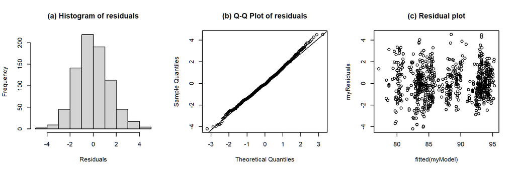

```
## Formula:  e_f0 ~ foot_syls + pre_syls + fin_phon + nuc_new_word + (1 | speaker) + (1 | speech_rate) + (1 | nuc_str_syl) + (1 | nuc_pre_text)
##
## Linear mixed model fit by REML. t-tests use Satterthwaite's method [
## lmerModLmerTest]
## Formula: e_f0_equation
##    Data: nuc_e_f0.trimmed
## Control:
## lmerControl(optimizer = optimizer, calc.derivs = FALSE, optCtrl = list(method = "nlminb",
##     starttests = FALSE, kkt = FALSE))
##
## REML criterion at convergence: 3075.5
##
## Scaled residuals:
##      Min       1Q   Median       3Q      Max
## -2.72496 -0.65603 -0.06684  0.58158  2.93198
##
## Random effects:
##  Groups       Name        Variance Std.Dev.
##  speech_rate  (Intercept)  0.29774 0.5457
##  nuc_pre_text (Intercept)  0.24119 0.4911
##  speaker      (Intercept) 24.55497 4.9553
##  nuc_str_syl  (Intercept)  0.03335 0.1826
##  Residual                  2.37208 1.5402
## Number of obs: 785, groups:
## speech_rate, 634; nuc_pre_text, 12; speaker, 11; nuc_str_syl, 3
##
## Fixed effects:
##                  Estimate Std. Error       df t value Pr(>|t|)
## (Intercept)       86.3804     1.6707  11.6688  51.702 3.80e-15 ***
## foot_syls2         1.3614     0.7573   2.2537   1.798    0.200
## foot_syls3         1.6671     0.2384 724.1242   6.993 6.12e-12 ***
## foot_syls4         1.5527     0.8860   3.1647   1.752    0.173
## pre_syls1          0.5023     0.7349   1.9981   0.684    0.565
## pre_syls2          0.2802     0.9687   2.9365   0.289    0.792
## pre_syls3          0.2839     0.9696   3.0098   0.293    0.789
## fin_phonL%        -5.5842     0.3709 764.1147 -15.055  < 2e-16 ***
## nuc_new_wordTRUE   0.1816     0.4603   4.3736   0.395    0.712
## ---
## Signif. codes:  0 '***' 0.001 '**' 0.01 '*' 0.05 '.' 0.1 ' ' 1
##
```

[output cut: 24 more lines]

```
## Backward reduced fixed-effect table:
## Degrees of freedom method: Satterthwaite
##
##              Eliminated Sum Sq Mean Sq NumDF  DenDF  F value    Pr(>F)
## pre_syls              1   1.71    0.57     3   4.44   0.2141    0.8823
## nuc_new_word          2   0.34    0.34     1   7.62   0.1275    0.7308
## foot_syls             0 141.49   47.16     3  14.52  17.6770 4.093e-05 ***
## fin_phon              0 609.64  609.64     1 769.05 228.5026 < 2.2e-16 ***
## ---
## Signif. codes:  0 '***' 0.001 '**' 0.01 '*' 0.05 '.' 0.1 ' ' 1
##
## Model found:
## e_f0 ~ foot_syls + fin_phon + (1 | speaker) + (1 | nuc_pre_text)
##
## isSingular(my_model, tol = 1e-05 ) --> FALSE
```

Anova of model: e_f0 ~ foot_syls + pre_syls + fin_phon + nuc_new_word + (1 | speaker) + (1 | speech_rate) + (1 | nuc_str_syl) + (1 | nuc_pre_text)

| term | sumsq | meansq | NumDF | DenDF | F value | p.value | signif. |
| --- | --- | --- | --- | --- | --- | --- | --- |
| foot_syls | 119.116 | 39.705 | 3 | 3.195 | 16.739 | 1.892005e-02 | p<0.05 |
| pre_syls | 1.430 | 0.477 | 3 | 2.975 | 0.201 | 8.898340e-01 |  |
| fin_phon | 537.605 | 537.605 | 1 | 764.115 | 226.638 | 4.785622e-45 | p<0.001 |
| nuc_new_word | 0.369 | 0.369 | 1 | 4.374 | 0.156 | 7.116398e-01 |  |

Conditional and marginal R<sup>2</sup> of model

| R2_conditional | R2_marginal |
| --- | --- |
| 0.91 | 0.04 |

$foot_syls

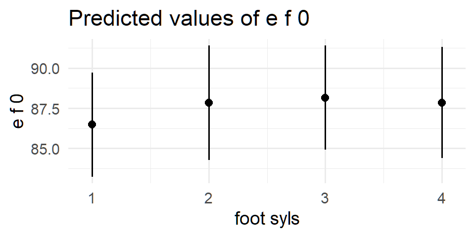

$pre_syls

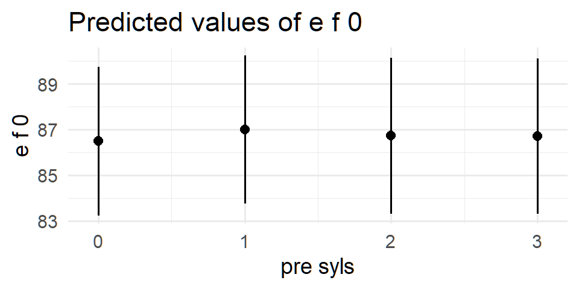

$fin_phon

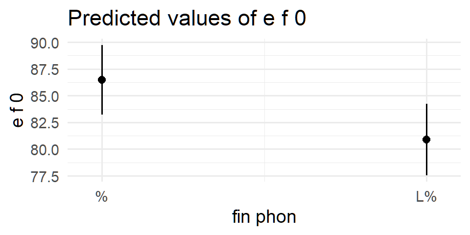

$nuc_new_word

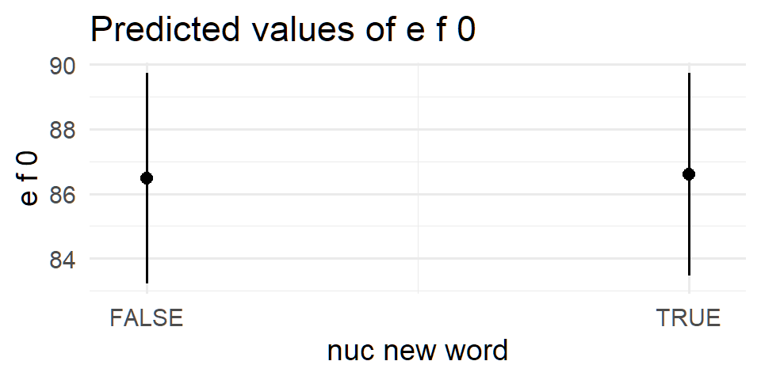

summary of model: e_f0 ~ foot_syls + pre_syls + fin_phon + nuc_new_word + (1 | speaker) + (1 | speech_rate) + (1 | nuc_str_syl) + (1 | nuc_pre_text)

| term | estimate | conf.low | conf.high | std.error | t.value | df | p.value |
| --- | --- | --- | --- | --- | --- | --- | --- |
| (Intercept) | 86.485 | 82.9132386 | 90.056198 | 1.658 | 52.170 | 13.36 | 7.8e-17 |
| foot_syls2 | 1.359 | -0.6828534 | 3.400837 | 0.770 | 1.766 | 4.53 | 0.1437 |
| foot_syls3 | 1.673 | 1.1919626 | 2.154687 | 0.245 | 6.825 | 721.62 | 1.9e-11 |
| foot_syls4 | 1.369 | -0.9885037 | 3.726635 | 0.889 | 1.540 | 4.54 | 0.1901 |
| pre_syls1 | 0.510 | -1.5616962 | 2.580892 | 0.746 | 0.683 | 4.00 | 0.5321 |
| pre_syls2 | 0.239 | -2.3971334 | 2.874741 | 0.972 | 0.246 | 4.26 | 0.8174 |
| pre_syls3 | 0.223 | -2.4130083 | 2.859957 | 0.972 | 0.230 | 4.26 | 0.8289 |
| fin_phonL% | -5.586 | -6.3357916 | -4.836430 | 0.382 | -14.627 | 767.65 | 6.4e-43 |
| nuc_new_wordTRUE | 0.120 | -1.0572747 | 1.297540 | 0.446 | 0.269 | 4.61 | 0.7995 |

b0 for e_f0 ~ foot_syls + pre_syls + fin_phon + nuc_new_word + (1 | speaker) + (1 | speech_rate) + (1 | nuc_str_syl) + (1 | nuc_pre_text)

| intercept | estimate | conf.low | conf.high | std.error | t.value | df | p.value |
| --- | --- | --- | --- | --- | --- | --- | --- |
| foot_syls1 | 86.4 | 82.7 | 90 | 1.67 | 51.70 | 11.67 | 3.8e-15 |
| foot_syls2 | 87.7 | 83.8 | 91.7 | 1.83 | 47.99 | 14.28 | 3.4e-17 |
| foot_syls3 | 88 | 84.4 | 91.7 | 1.67 | 52.71 | 11.66 | 3.1e-15 |
| foot_syls4 | 87.9 | 84.1 | 91.7 | 1.76 | 50.01 | 13.35 | 1.4e-16 |
| pre_syls0 | 86.4 | 82.7 | 90 | 1.67 | 51.70 | 11.67 | 3.8e-15 |
| pre_syls1 | 86.9 | 83.2 | 90.5 | 1.67 | 51.99 | 11.68 | 3.5e-15 |
| pre_syls2 | 86.7 | 82.9 | 90.4 | 1.74 | 49.86 | 14.02 | 3.5e-17 |
| pre_syls3 | 86.7 | 82.9 | 90.4 | 1.74 | 49.87 | 13.97 | 3.8e-17 |

b1 for e_f0 ~ foot_syls + pre_syls + fin_phon + nuc_new_word + (1 | speaker) + (1 | speech_rate) + (1 | nuc_str_syl) + (1 | nuc_pre_text)

| intercept | slope | estimate | conf.low | conf.high | std.error | t.value | df | p.value |
| --- | --- | --- | --- | --- | --- | --- | --- | --- |
| foot_syls1 | foot_syls2 | 1.36 | -1.57 | 4.293 | 0.760 | 1.800 | 2.25 | 0.2 |
| foot_syls1 | foot_syls3 | 1.67 | 1.199 | 2.135 | 0.240 | 6.990 | 724.12 | 6.1e-12 |
| foot_syls1 | foot_syls4 | 1.55 | -1.186 | 4.291 | 0.890 | 1.750 | 3.16 | 0.173 |
| foot_syls2 | foot_syls3 | 0.31 | -2.56 | 3.172 | 0.770 | 0.400 | 2.35 | 0.723 |
| foot_syls2 | foot_syls4 | 0.19 | -2.528 | 2.911 | 0.890 | 0.210 | 3.25 | 0.843 |
| foot_syls3 | foot_syls4 | -0.11 | -2.834 | 2.605 | 0.890 | -0.130 | 3.25 | 0.905 |
| pre_syls0 | pre_syls1 | 0.5 | -2.663 | 3.667 | 0.730 | 0.680 | 2.00 | 0.565 |
| pre_syls0 | pre_syls2 | 0.28 | -2.841 | 3.401 | 0.970 | 0.290 | 2.94 | 0.792 |
| pre_syls0 | pre_syls3 | 0.28 | -2.796 | 3.364 | 0.970 | 0.290 | 3.01 | 0.789 |
| pre_syls1 | pre_syls2 | -0.22 | -1.897 | 1.452 | 0.630 | -0.350 | 4.53 | 0.741 |
| pre_syls1 | pre_syls3 | -0.22 | -1.882 | 1.445 | 0.630 | -0.350 | 4.64 | 0.745 |
| pre_syls2 | pre_syls3 | 0.0e+00 | -1.147 | 1.155 | 0.400 | 0.010 | 3.68 | 0.993 |
| intercept | fin_phonL% | -5.584 | -6.312 | -4.856 | 0.371 | -15.055 | 764.11 | 4.8e-45 |
| intercept | nuc_new_wordTRUE | 0.182 | -1.054 | 1.418 | 0.460 | 0.395 | 4.37 | 0.712 |

## Truncation and Compression Effects

- step() suggests: `f0_exc ~ foot_syls + fin_phon + (1 | speaker) + (1 | nuc_pre_text)`
- model works after removing random intercepts of speech_rate, nuc_str_syl, and foot_dur. ### LH Excursion
- model needs trimming (|sd| residuals > 2.5)

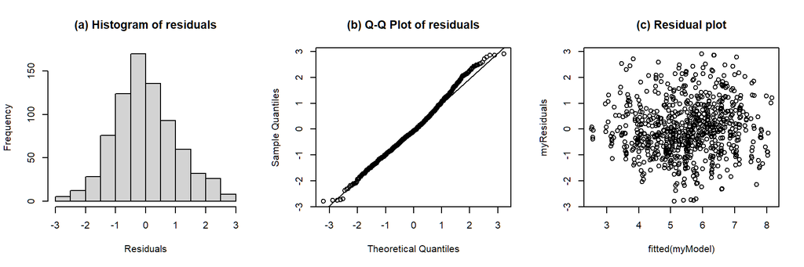

```
## Formula:  f0_exc ~ foot_syls + pre_syls + fin_phon + nuc_new_word + gender + (1 | speaker) + (1 | speech_rate) + (1 | nuc_str_syl) + (1 | nuc_pre_text)
##
## Linear mixed model fit by REML. t-tests use Satterthwaite's method [
## lmerModLmerTest]
## Formula: f0_exc_equation
##    Data: nuc_f0_exc.trimmed
## Control:
## lmerControl(optimizer = optimizer, calc.derivs = FALSE, optCtrl = list(method = "nlminb",
##     starttests = FALSE, kkt = FALSE))
##
## REML criterion at convergence: 2402.1
##
## Scaled residuals:
##      Min       1Q   Median       3Q      Max
## -2.59007 -0.63631 -0.07009  0.60236  2.71263
##
## Random effects:
##  Groups       Name        Variance  Std.Dev.
##  speech_rate  (Intercept) 6.803e-02 2.608e-01
##  nuc_pre_text (Intercept) 4.732e-01 6.879e-01
##  speaker      (Intercept) 9.046e-01 9.511e-01
##  nuc_str_syl  (Intercept) 4.936e-09 7.026e-05
##  Residual                 1.151e+00 1.073e+00
## Number of obs: 770, groups:
## speech_rate, 623; nuc_pre_text, 12; speaker, 11; nuc_str_syl, 3
##
## Fixed effects:
##                  Estimate Std. Error       df t value Pr(>|t|)
## (Intercept)        3.4061     0.9869   6.7321   3.451  0.01135 *
## foot_syls2         0.4040     0.9940   4.8996   0.406  0.70154
## foot_syls3         1.9218     0.1609 708.0964  11.947  < 2e-16 ***
## foot_syls4         1.5235     1.1485   4.9122   1.326  0.24301
## pre_syls1          0.5984     0.9863   4.7486   0.607  0.57189
## pre_syls2          1.3808     1.2701   4.8219   1.087  0.32833
## pre_syls3          1.2861     1.2704   4.8255   1.012  0.35942
## fin_phonL%        -0.8203     0.2546 750.4070  -3.222  0.00133 **
## nuc_new_wordTRUE   0.5711     0.5750   4.9376   0.993  0.36676
## genderM            0.4200     0.5815   8.9970   0.722  0.48849
## ---
## Signif. codes:  0 '***' 0.001 '**' 0.01 '*' 0.05 '.' 0.1 ' ' 1
```

[output cut: 30 more lines]

```
## Degrees of freedom method: Satterthwaite
##
##              Eliminated  Sum Sq Mean Sq NumDF  DenDF F value    Pr(>F)
## pre_syls              1   1.620   0.540     3   4.88  0.4431  0.732841
## gender                2   0.636   0.636     1   9.00  0.5223  0.488218
## nuc_new_word          3   0.999   0.999     1   7.91  0.8201  0.391899
## foot_syls             0 174.879  58.293     3  12.34 47.8332 4.594e-07 ***
## fin_phon              0  12.517  12.517     1 751.78 10.2707  0.001409 **
## ---
## Signif. codes:  0 '***' 0.001 '**' 0.01 '*' 0.05 '.' 0.1 ' ' 1
##
## Model found:
## f0_exc ~ foot_syls + fin_phon + (1 | speaker) + (1 | nuc_pre_text)
##
## isSingular(my_model, tol = 1e-05 ) --> FALSE
```

Anova of model: f0_exc ~ foot_syls + pre_syls + fin_phon + nuc_new_word + gender + (1 | speaker) + (1 | speech_rate) + (1 | nuc_str_syl) + (1 | nuc_pre_text)

| term | sumsq | meansq | NumDF | DenDF | F value | p.value | signif. |
| --- | --- | --- | --- | --- | --- | --- | --- |
| foot_syls | 165.275 | 55.092 | 3 | 6.367 | 47.879 | 9.435715e-05 | p<0.001 |
| pre_syls | 1.540 | 0.513 | 3 | 4.875 | 0.446 | 7.310753e-01 |  |
| fin_phon | 11.946 | 11.946 | 1 | 750.407 | 10.382 | 1.327587e-03 | p<0.01 |
| nuc_new_word | 1.135 | 1.135 | 1 | 4.938 | 0.986 | 3.667586e-01 |  |
| gender | 0.600 | 0.600 | 1 | 8.997 | 0.522 | 4.884916e-01 |  |

Conditional and marginal R<sup>2</sup> of model

| R2_conditional | R2_marginal |
| --- | --- |
| 0.61 | 0.13 |

$foot_syls

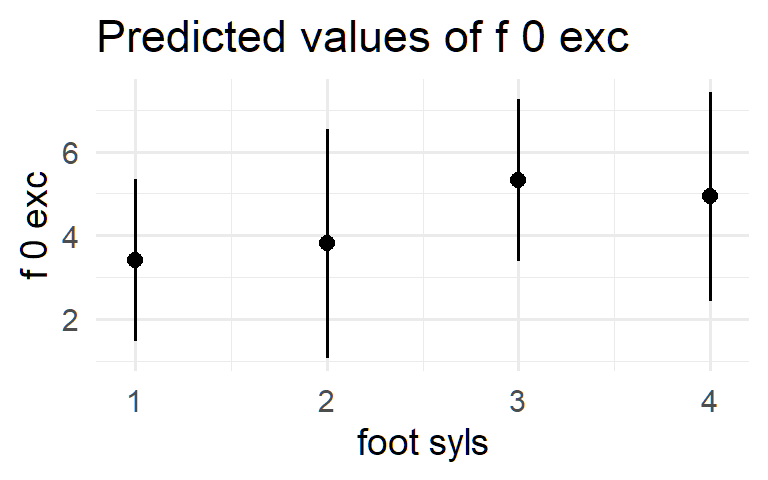

$pre_syls

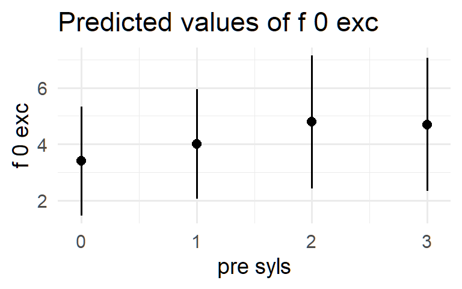

$fin_phon

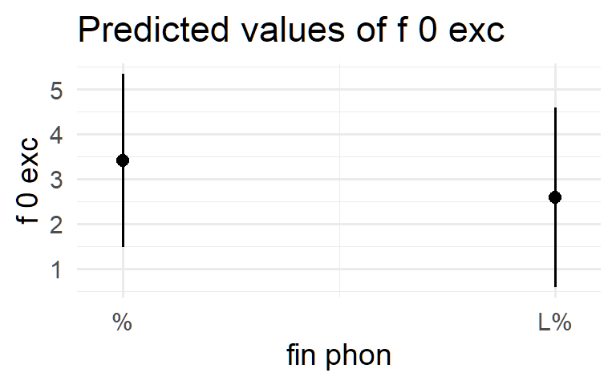

$nuc_new_word

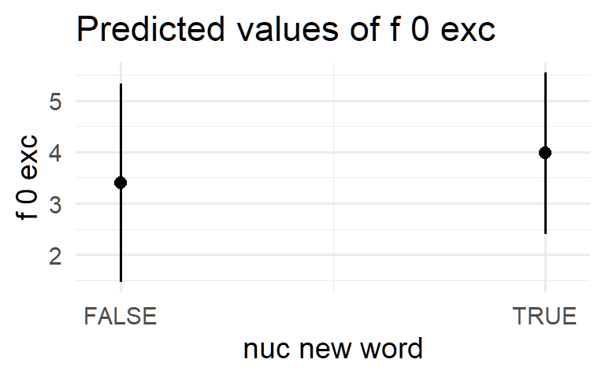

$gender

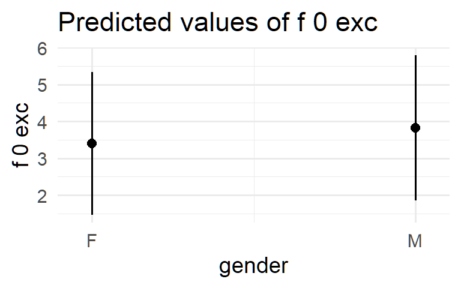

summary of model: f0_exc ~ foot_syls + pre_syls + fin_phon + nuc_new_word + gender + (1 | speaker) + (1 | speech_rate) + (1 | nuc_str_syl) + (1 | nuc_pre_text)

| term | estimate | conf.low | conf.high | std.error | t.value | df | p.value |
| --- | --- | --- | --- | --- | --- | --- | --- |
| (Intercept) | 3.406 | 1.0534036 | 5.7588307 | 0.987 | 3.451 | 6.73 | 0.0113 |
| foot_syls2 | 0.404 | -2.1670154 | 2.9750883 | 0.994 | 0.406 | 4.90 | 0.7015 |
| foot_syls3 | 1.922 | 1.6059903 | 2.2376650 | 0.161 | 11.947 | 708.10 | 4.3e-30 |
| foot_syls4 | 1.523 | -1.4448922 | 4.4918791 | 1.149 | 1.326 | 4.91 | 0.243 |
| pre_syls1 | 0.598 | -1.9778636 | 3.1745837 | 0.986 | 0.607 | 4.75 | 0.5719 |
| pre_syls2 | 1.381 | -1.9208776 | 4.6823793 | 1.270 | 1.087 | 4.82 | 0.3283 |
| pre_syls3 | 1.286 | -2.0154643 | 4.5876027 | 1.270 | 1.012 | 4.83 | 0.3594 |
| fin_phonL% | -0.820 | -1.3200423 | -0.3205011 | 0.255 | -3.222 | 750.41 | 0.0013 |
| nuc_new_wordTRUE | 0.571 | -0.9126783 | 2.0549196 | 0.575 | 0.993 | 4.94 | 0.3668 |
| genderM | 0.420 | -0.8955677 | 1.7355734 | 0.582 | 0.722 | 9.00 | 0.4885 |

b0 for f0_exc ~ foot_syls + pre_syls + fin_phon + nuc_new_word + gender + (1 | speaker) + (1 | speech_rate) + (1 | nuc_str_syl) + (1 | nuc_pre_text)

| intercept | estimate | conf.low | conf.high | std.error | t.value | df | p.value |
| --- | --- | --- | --- | --- | --- | --- | --- |
| foot_syls1 | 3.41 | 1.053 | 5.759 | 0.99 | 3.45 | 6.73 | 0.011 |
| foot_syls2 | 3.81 | 0.342 | 7.278 | 1.40 | 2.73 | 5.67 | 0.036 |
| foot_syls3 | 5.33 | 2.975 | 7.681 | 0.99 | 5.40 | 6.73 | 0.001 |
| foot_syls4 | 4.93 | 1.792 | 8.067 | 1.27 | 3.87 | 5.83 | 0.009 |
| pre_syls0 | 3.41 | 1.053 | 5.759 | 0.99 | 3.45 | 6.73 | 0.011 |
| pre_syls1 | 4 | 1.652 | 6.357 | 0.99 | 4.06 | 6.74 | 0.005 |
| pre_syls2 | 4.79 | 1.85 | 7.724 | 1.20 | 3.98 | 6.08 | 0.007 |
| pre_syls3 | 4.69 | 1.755 | 7.629 | 1.20 | 3.90 | 6.08 | 0.008 |

b1 for f0_exc ~ foot_syls + pre_syls + fin_phon + nuc_new_word + gender + (1 | speaker) + (1 | speech_rate) + (1 | nuc_str_syl) + (1 | nuc_pre_text)

| intercept | slope | estimate | conf.low | conf.high | std.error | t.value | df | p.value |
| --- | --- | --- | --- | --- | --- | --- | --- | --- |
| foot_syls1 | foot_syls2 | 0.4 | -2.167 | 2.975 | 0.990 | 0.410 | 4.90 | 0.702 |
| foot_syls1 | foot_syls3 | 1.92 | 1.606 | 2.238 | 0.160 | 11.950 | 708.10 | 4.3e-30 |
| foot_syls1 | foot_syls4 | 1.52 | -1.445 | 4.492 | 1.150 | 1.330 | 4.91 | 0.243 |
| foot_syls2 | foot_syls3 | 1.52 | -1.052 | 4.087 | 1.000 | 1.520 | 4.95 | 0.189 |
| foot_syls2 | foot_syls4 | 1.12 | -1.848 | 4.087 | 1.150 | 0.970 | 4.94 | 0.376 |
| foot_syls3 | foot_syls4 | -0.4 | -3.366 | 2.569 | 1.150 | -0.350 | 4.95 | 0.743 |
| pre_syls0 | pre_syls1 | 0.6 | -1.978 | 3.175 | 0.990 | 0.610 | 4.75 | 0.572 |
| pre_syls0 | pre_syls2 | 1.38 | -1.921 | 4.682 | 1.270 | 1.090 | 4.82 | 0.328 |
| pre_syls0 | pre_syls3 | 1.29 | -2.015 | 4.588 | 1.270 | 1.010 | 4.83 | 0.359 |
| pre_syls1 | pre_syls2 | 0.78 | -1.283 | 2.848 | 0.800 | 0.980 | 4.94 | 0.374 |
| pre_syls1 | pre_syls3 | 0.69 | -1.378 | 2.753 | 0.800 | 0.860 | 4.94 | 0.43 |
| pre_syls2 | pre_syls3 | -0.09 | -1.38 | 1.19 | 0.500 | -0.190 | 4.94 | 0.857 |
| intercept | fin_phonL% | -0.82 | -1.32 | -0.321 | 0.255 | -3.222 | 750.41 | 0.001 |
| intercept | nuc_new_wordTRUE | 0.571 | -0.913 | 2.055 | 0.575 | 0.993 | 4.94 | 0.367 |
| intercept | genderM | 0.42 | -0.896 | 1.736 | 0.582 | 0.722 | 9.00 | 0.488 |

### LH Slope

Based on results from tonal target analysis, it looksl like compression and truncation may be in effect. As compression leads to decrease in duration of rise (but not necessarily much descrease in excursion size), and as slope increases exponentially as duration decreases, slope has been logged here.

initial step() suggests: `log_lh_slope ~ foot_syls + (1 | speaker) + (1 | nuc_pre_text)` - model works once random intercepts of speech_rate and foot_dur removed

- model needs trimming (|sd| residuals > 3.5)

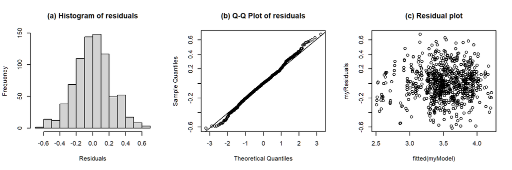

```
## Formula:  log_lh_slope ~ foot_syls + pre_syls + fin_phon + nuc_new_word + gender + (1 | speaker) + (1 | speech_rate) + (1 | nuc_str_syl) + (1 | nuc_pre_text)
##
## Linear mixed model fit by REML. t-tests use Satterthwaite's method [
## lmerModLmerTest]
## Formula: lh_slope_equation
##    Data: nuc_lh_slope.trimmed
## Control:
## lmerControl(optimizer = optimizer, calc.derivs = FALSE, optCtrl = list(method = "nlminb",
##     starttests = FALSE, kkt = FALSE))
##
## REML criterion at convergence: 65.2
##
## Scaled residuals:
##      Min       1Q   Median       3Q      Max
## -2.67924 -0.60366  0.00844  0.59534  2.95188
##
## Random effects:
##  Groups       Name        Variance  Std.Dev.
##  speech_rate  (Intercept) 3.481e-03 5.900e-02
##  nuc_pre_text (Intercept) 1.351e-02 1.162e-01
##  speaker      (Intercept) 5.259e-02 2.293e-01
##  nuc_str_syl  (Intercept) 2.410e-09 4.909e-05
##  Residual                 5.285e-02 2.299e-01
## Number of obs: 782, groups:
## speech_rate, 633; nuc_pre_text, 12; speaker, 11; nuc_str_syl, 3
##
## Fixed effects:
##                   Estimate Std. Error        df t value Pr(>|t|)
## (Intercept)        3.20673    0.18131   8.38778  17.686  6.2e-08 ***
## foot_syls2        -0.02166    0.17007   4.83692  -0.127 0.903768
## foot_syls3        -0.12888    0.03464 715.48289  -3.721 0.000214 ***
## foot_syls4        -0.70646    0.19645   4.84437  -3.596 0.016476 *
## pre_syls1          0.27147    0.16801   4.60662   1.616 0.172010
## pre_syls2          0.37343    0.21685   4.72019   1.722 0.149138
## pre_syls3          0.39106    0.21689   4.72276   1.803 0.134662
## fin_phonL%         0.09586    0.05394 762.68855   1.777 0.075928 .
## nuc_new_wordTRUE   0.06746    0.09844   4.88626   0.685 0.524299
## genderM            0.10834    0.13992   9.01181   0.774 0.458562
## ---
## Signif. codes:  0 '***' 0.001 '**' 0.01 '*' 0.05 '.' 0.1 ' ' 1
```

[output cut: 27 more lines]

```
## Degrees of freedom method: Satterthwaite
##
##              Eliminated Sum Sq Mean Sq NumDF  DenDF F value    Pr(>F)
## nuc_new_word          1 0.0252 0.02524     1   4.89  0.4482   0.53351
## gender                2 0.0335 0.03348     1   9.01  0.5944   0.46047
## pre_syls              3 0.2038 0.06792     3   5.66  1.2060   0.38887
## fin_phon              4 0.1814 0.18135     1 764.32  3.2201   0.07313 .
## foot_syls             0 3.4396 1.14654     3  12.01 20.3013 5.371e-05 ***
## ---
## Signif. codes:  0 '***' 0.001 '**' 0.01 '*' 0.05 '.' 0.1 ' ' 1
##
## Model found:
## log_lh_slope ~ foot_syls + (1 | speaker) + (1 | nuc_pre_text)
##
## isSingular(my_model, tol = 1e-05 ) --> FALSE
```

Anova of model: log_lh_slope ~ foot_syls + pre_syls + fin_phon + nuc_new_word + gender + (1 | speaker) + (1 | speech_rate) + (1 | nuc_str_syl) + (1 | nuc_pre_text)

| term | sumsq | meansq | NumDF | DenDF | F value | p.value | signif. |
| --- | --- | --- | --- | --- | --- | --- | --- |
| foot_syls | 1.485 | 0.495 | 3 | 6.280 | 9.367 | 0.009930165 | p<0.01 |
| pre_syls | 0.178 | 0.059 | 3 | 4.793 | 1.125 | 0.425250962 |  |
| fin_phon | 0.167 | 0.167 | 1 | 762.689 | 3.159 | 0.075928382 |  |
| nuc_new_word | 0.025 | 0.025 | 1 | 4.886 | 0.470 | 0.524299468 |  |
| gender | 0.032 | 0.032 | 1 | 9.012 | 0.600 | 0.458562179 |  |

Conditional and marginal R<sup>2</sup> of model

| R2_conditional | R2_marginal |
| --- | --- |
| 0.71 | 0.33 |

$foot_syls

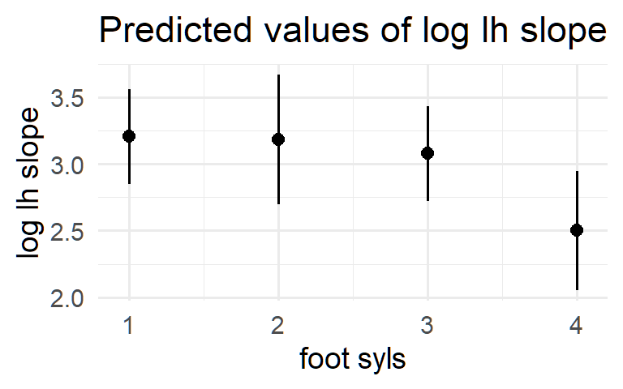

$pre_syls

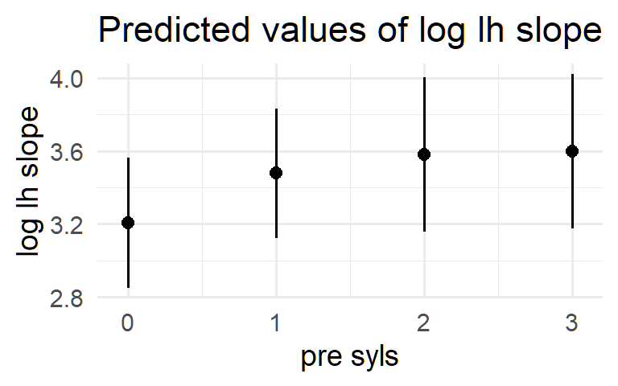

$fin_phon

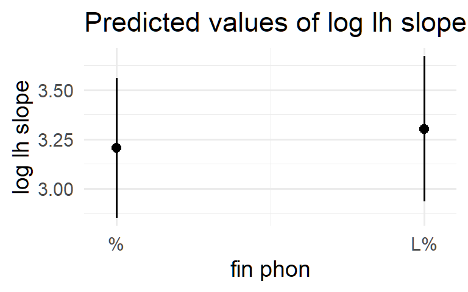

$nuc_new_word

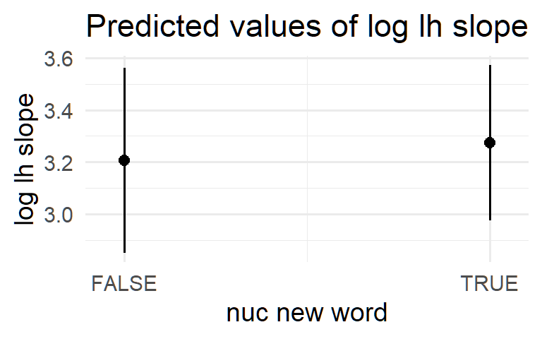

$gender

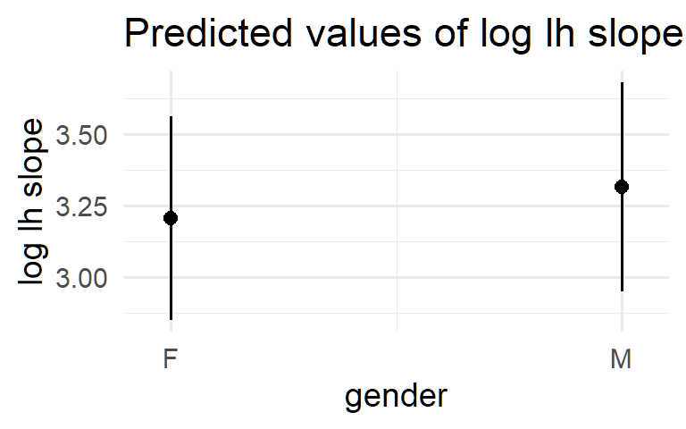

summary of model: log_lh_slope ~ foot_syls + pre_syls + fin_phon + nuc_new_word + gender + (1 | speaker) + (1 | speech_rate) + (1 | nuc_str_syl) + (1 | nuc_pre_text)

| term | estimate | conf.low | conf.high | std.error | t.value | df | p.value |
| --- | --- | --- | --- | --- | --- | --- | --- |
| (Intercept) | 3.207 | 2.79196818 | 3.62149689 | 0.181 | 17.686 | 8.39 | 6.2e-08 |
| foot_syls2 | -0.022 | -0.46331256 | 0.41998687 | 0.170 | -0.127 | 4.84 | 0.9038 |
| foot_syls3 | -0.129 | -0.19689240 | -0.06087327 | 0.035 | -3.721 | 715.48 | 2e-04 |
| foot_syls4 | -0.706 | -1.21637329 | -0.19654390 | 0.196 | -3.596 | 4.84 | 0.0165 |
| pre_syls1 | 0.271 | -0.17173987 | 0.71468351 | 0.168 | 1.616 | 4.61 | 0.172 |
| pre_syls2 | 0.373 | -0.19408606 | 0.94094410 | 0.217 | 1.722 | 4.72 | 0.1491 |
| pre_syls3 | 0.391 | -0.17645095 | 0.95857753 | 0.217 | 1.803 | 4.72 | 0.1347 |
| fin_phonL% | 0.096 | -0.01002395 | 0.20174032 | 0.054 | 1.777 | 762.69 | 0.0759 |
| nuc_new_wordTRUE | 0.067 | -0.18737402 | 0.32230123 | 0.098 | 0.685 | 4.89 | 0.5243 |
| genderM | 0.108 | -0.20810978 | 0.42479890 | 0.140 | 0.774 | 9.01 | 0.4586 |

b0 for log_lh_slope ~ foot_syls + pre_syls + fin_phon + nuc_new_word + gender + (1 | speaker) + (1 | speech_rate) + (1 | nuc_str_syl) + (1 | nuc_pre_text)

| intercept | estimate | conf.low | conf.high | std.error | t.value | df | p.value |
| --- | --- | --- | --- | --- | --- | --- | --- |
| foot_syls1 | 3.21 | 2.792 | 3.621 | 0.18 | 17.69 | 8.39 | 6.2e-08 |
| foot_syls2 | 3.19 | 2.588 | 3.782 | 0.25 | 12.86 | 6.38 | 8.5e-06 |
| foot_syls3 | 3.08 | 2.663 | 3.493 | 0.18 | 16.98 | 8.38 | 8.7e-08 |
| foot_syls4 | 2.5 | 1.958 | 3.042 | 0.23 | 11.01 | 6.69 | 1.6e-05 |
| pre_syls0 | 3.21 | 2.792 | 3.621 | 0.18 | 17.69 | 8.39 | 6.2e-08 |
| pre_syls1 | 3.48 | 3.063 | 3.893 | 0.18 | 19.18 | 8.40 | 3.1e-08 |
| pre_syls2 | 3.58 | 3.071 | 4.09 | 0.22 | 16.54 | 7.15 | 5.8e-07 |
| pre_syls3 | 3.6 | 3.088 | 4.107 | 0.22 | 16.63 | 7.15 | 5.6e-07 |

b1 for log_lh_slope ~ foot_syls + pre_syls + fin_phon + nuc_new_word + gender + (1 | speaker) + (1 | speech_rate) + (1 | nuc_str_syl) + (1 | nuc_pre_text)

| intercept | slope | estimate | conf.low | conf.high | std.error | t.value | df | p.value |
| --- | --- | --- | --- | --- | --- | --- | --- | --- |
| foot_syls1 | foot_syls2 | -0.02 | -0.463 | 0.42 | 0.170 | -0.130 | 4.84 | 0.904 |
| foot_syls1 | foot_syls3 | -0.13 | -0.197 | -0.061 | 0.030 | -3.720 | 715.48 | 2.1e-04 |
| foot_syls1 | foot_syls4 | -0.71 | -1.216 | -0.197 | 0.200 | -3.600 | 4.84 | 0.016 |
| foot_syls2 | foot_syls3 | -0.11 | -0.548 | 0.334 | 0.170 | -0.630 | 4.92 | 0.558 |
| foot_syls2 | foot_syls4 | -0.68 | -1.194 | -0.175 | 0.200 | -3.480 | 4.90 | 0.018 |
| foot_syls3 | foot_syls4 | -0.58 | -1.087 | -0.068 | 0.200 | -2.930 | 4.90 | 0.033 |
| pre_syls0 | pre_syls1 | 0.27 | -0.172 | 0.715 | 0.170 | 1.620 | 4.61 | 0.172 |
| pre_syls0 | pre_syls2 | 0.37 | -0.194 | 0.941 | 0.220 | 1.720 | 4.72 | 0.149 |
| pre_syls0 | pre_syls3 | 0.39 | -0.176 | 0.959 | 0.220 | 1.800 | 4.72 | 0.135 |
| pre_syls1 | pre_syls2 | 0.1 | -0.253 | 0.457 | 0.140 | 0.740 | 4.90 | 0.491 |
| pre_syls1 | pre_syls3 | 0.12 | -0.235 | 0.474 | 0.140 | 0.870 | 4.90 | 0.424 |
| pre_syls2 | pre_syls3 | 0.02 | -0.203 | 0.238 | 0.090 | 0.210 | 4.89 | 0.844 |
| intercept | fin_phonL% | 0.096 | -0.01 | 0.202 | 0.054 | 1.777 | 762.69 | 0.076 |
| intercept | nuc_new_wordTRUE | 0.067 | -0.187 | 0.322 | 0.098 | 0.685 | 4.89 | 0.524 |
| intercept | genderM | 0.108 | -0.208 | 0.425 | 0.140 | 0.774 | 9.01 | 0.459 |